# Question 1: Which type of sample, biopsy or peripheral blood, is a better predictor of kidney transplant success, and which gene is the most influential in determining success in the early stages?

# 5 Data Modeling - Applied Machine Learning

Apply the machine learning models to predict patient rejection status from gene expression data.

Large p small n

## 5.1 In-sample

```r
gene4blood <- rownames(top4blood)[1:10]
gene4biopsy <- rownames(top4biopsy)[1:10]

X_gse4b = t(exprs(gset4blood)[ gene4blood, ])
y_gse4b = ifelse(grepl("AR", gset4blood$title), "Rejection", "Stable")
X_gse1b = t(exprs(gset4biopsy)[ gene4biopsy, ])
y_gse1b = ifelse(grepl("AR", gset4biopsy$title), "Stable","Rejection")

#In sample

#Framework 1 (SVM)

set.seed(3888)

cvK = 5    # Number of CV folds
n_sim = 50 # Number of repeats

# SVM CV for (blood)

cv_accuracy_gse4b = numeric(n_sim)

for (i in 1:n_sim) {

  cvSets = cvFolds(nrow(X_gse4b), cvK)
  cv_accuracy_folds = numeric(cvK)

  for (j in 1:cvK) {
    test_id = cvSets$subsets[cvSets$which == j]
    X_train = X_gse4b[-test_id,]
    X_test = X_gse4b[test_id,]
    y_train = y_gse4b[-test_id]
    y_test = y_gse4b[test_id]

    svm_fit4blood = svm(x = X_train, y = as.factor(y_train))
    predictions = predict(svm_fit4blood, X_test)
    cv_accuracy_folds[j] = mean(y_test == predictions)
  }
  cv_accuracy_gse4b[i] = mean(cv_accuracy_folds)
}

# SVM CV for (biopsy)

cv_accuracy_gse1b = numeric(n_sim) # Vector to store averaged CV accuracies

for (i in 1:n_sim) {

  cvSets = cvFolds(nrow(X_gse1b), cvK) # Folds object for cross-validation
  cv_accuracy_folds = numeric(cvK) # Vector to store accuracy for each fold

  for (j in 1:cvK) {
    test_id = cvSets$subsets[cvSets$which == j]
    X_train = X_gse1b[-test_id,]
    X_test = X_gse1b[test_id,]
    y_train = y_gse1b[-test_id]
    y_test = y_gse1b[test_id]

    svm_fit4biopsy = svm(x = X_train, y = as.factor(y_train))
    predictions = predict(svm_fit4biopsy, X_test)
    cv_accuracy_folds[j] = mean(y_test == predictions)
  }
  cv_accuracy_gse1b[i] = mean(cv_accuracy_folds)
}
```

## 5.2 Out-of-sample

```r
X_gse4c = t(exprs(gset4blood))
y_gse4c = ifelse(grepl("AR", gset4blood$title), "Rejection", "Stable")
X_gse1c = t(exprs(gset4biopsy))
y_gse1c = ifelse(grepl("AR", gset4biopsy$title), "Stable","Rejection")


set.seed(3888)

cvK = 5    # Number of CV folds
n_sim = 50 # Number of repeats

# SVM CV for (blood)

cv_accuracy_gse4c = numeric(n_sim)

for (i in 1:n_sim) {

  cvSets = cvFolds(nrow(X_gse4b), cvK)
  cv_accuracy_folds = numeric(cvK)

  for (j in 1:cvK) {
    test_id = cvSets$subsets[cvSets$which == j]
    X_train = X_gse4c[-test_id,]
    X_test = X_gse4c[test_id,]
    y_train = y_gse4c[-test_id]
    y_test = y_gse4c[test_id]

    design5 <- model.matrix(~y_train)
    fit5  <- lmFit(t(X_train), design5)
    fit5   <- eBayes(fit5)
    top5  <- topTable(fit5, n = 10)
    DE_genes <- rownames(top5)

    X_train = X_train[,DE_genes]
    X_test = X_test[,DE_genes]

    svm_fit4bloodout = svm(x = X_train, y = as.factor(y_train), kernel = "linear")
    predictions = predict(svm_fit4bloodout, X_test)
    cv_accuracy_folds[j] = mean(y_test == predictions)
  }
  cv_accuracy_gse4c[i] = mean(cv_accuracy_folds)
}

# SVM CV for (biopsy)

cv_accuracy_gse1c = numeric(n_sim) # Vector to store averaged CV accuracies

for (i in 1:n_sim) {

  cvSets = cvFolds(nrow(X_gse1c), cvK) # Folds object for cross-validation
  cv_accuracy_folds = numeric(cvK) # Vector to store accuracy for each fold

  for (j in 1:cvK) {
    test_id = cvSets$subsets[cvSets$which == j]
    X_train = X_gse1c[-test_id,]
    X_test = X_gse1c[test_id,]
    y_train = y_gse1c[-test_id]
    y_test = y_gse1c[test_id]

    design5 <- model.matrix(~y_train)
    fit5  <- lmFit(t(X_train), design5)
    fit5   <- eBayes(fit5)
    top5  <- topTable(fit5, n = 10)
    DE_genes <- rownames(top5)

    X_train = X_train[,DE_genes]
    X_test = X_test[,DE_genes]

    svm_fit4biopsyout = svm(x = X_train, y = as.factor(y_train), kernel = "linear")
    predictions = predict(svm_fit4biopsyout, X_test)
    cv_accuracy_folds[j] = mean(y_test == predictions)
  }
  cv_accuracy_gse1c[i] = mean(cv_accuracy_folds)
}
```

```r
## Out-of-sample

X_gse4c = t(exprs(gset4blood))
y_gse4c = ifelse(grepl("AR", gset4blood$title), "Rejection", "Stable")
X_gse1c = t(exprs(gset4biopsy))
y_gse1c = ifelse(grepl("AR", gset4biopsy$title), "Stable", "Rejection")
X_gse4c2 = t(exprs(gset4blood2))
y_gse4c2 = ifelse(grepl("AR", gset4blood2$title), "Rejection", "Stable")
X_gse1c2 = t(exprs(gset4biopsy2))
y_gse1c2 = ifelse(grepl("AR", gset4biopsy2$title), "Stable", "Rejection")

set.seed(3888)

cvK = 5    # Number of CV folds
n_sim = 50 # Number of repeats

# SVM CV for (blood)
cv_accuracy_gse4c = numeric(n_sim)

for (i in 1:n_sim) {

  cvSets = cvFolds(nrow(X_gse4c), cvK)
  cv_accuracy_folds = numeric(cvK)

  for (j in 1:cvK) {
    test_id = cvSets$subsets[cvSets$which == j]
    X_train = X_gse4c[-test_id, ]
    X_test = X_gse4c[test_id, ]
    y_train = y_gse4c[-test_id]
    y_test = y_gse4c[test_id]

    design5 <- model.matrix(~y_train)
    fit5 <- lmFit(t(X_train), design5)
    fit5 <- eBayes(fit5)
    top5 <- topTable(fit5, n = 10)
    DE_genes <- rownames(top5)

    X_train = X_train[, DE_genes]
    X_test = X_test[, DE_genes]

    svm_fit4bloodout = svm(x = X_train, y = as.factor(y_train), kernel = "linear")
    predictions = predict(svm_fit4bloodout, X_test)
    cv_accuracy_folds[j] = mean(y_test == predictions)
  }
  cv_accuracy_gse4c[i] = mean(cv_accuracy_folds)
}

# SVM CV for (biopsy)
cv_accuracy_gse1c = numeric(n_sim) # Vector to store averaged CV accuracies

for (i in 1:n_sim) {

  cvSets = cvFolds(nrow(X_gse1c), cvK) # Folds object for cross-validation
  cv_accuracy_folds = numeric(cvK) # Vector to store accuracy for each fold

  for (j in 1:cvK) {
    test_id = cvSets$subsets[cvSets$which == j]
    X_train = X_gse1c[-test_id, ]
    X_test = X_gse1c[test_id, ]
    y_train = y_gse1c[-test_id]
    y_test = y_gse1c[test_id]

    design5 <- model.matrix(~y_train)
    fit5 <- lmFit(t(X_train), design5)
    fit5 <- eBayes(fit5)
    top5 <- topTable(fit5, n = 10)
    DE_genes <- rownames(top5)

    X_train = X_train[, DE_genes]
    X_test = X_test[, DE_genes]

    svm_fit4biopsyout = svm(x = X_train, y = as.factor(y_train), kernel = "linear")
    predictions = predict(svm_fit4biopsyout, X_test)
    cv_accuracy_folds[j] = mean(y_test == predictions)
  }
  cv_accuracy_gse1c[i] = mean(cv_accuracy_folds)
}

# SVM CV for (blood2)
cv_accuracy_gse4c2 = numeric(n_sim)

for (i in 1:n_sim) {

  cvSets = cvFolds(nrow(X_gse4c2), cvK)
  cv_accuracy_folds = numeric(cvK)

  for (j in 1:cvK) {
    test_id = cvSets$subsets[cvSets$which == j]
    X_train = X_gse4c2[-test_id, ]
    X_test = X_gse4c2[test_id, ]
    y_train = y_gse4c2[-test_id]
    y_test = y_gse4c2[test_id]

    design5 <- model.matrix(~y_train)
    fit5 <- lmFit(t(X_train), design5)
    fit5 <- eBayes(fit5)
    top5 <- topTable(fit5, n = 10)
    DE_genes <- rownames(top5)

    X_train = X_train[, DE_genes]
    X_test = X_test[, DE_genes]

    svm_fit4bloodout2 = svm(x = X_train, y = as.factor(y_train), kernel = "linear")
    predictions = predict(svm_fit4bloodout2, X_test)
    cv_accuracy_folds[j] = mean(y_test == predictions)
  }
  cv_accuracy_gse4c2[i] = mean(cv_accuracy_folds)
}

# SVM CV for (biopsy2)
cv_accuracy_gse1c2 = numeric(n_sim) # Vector to store averaged CV accuracies

for (i in 1:n_sim) {

  cvSets = cvFolds(nrow(X_gse1c2), cvK) # Folds object for cross-validation
  cv_accuracy_folds = numeric(cvK) # Vector to store accuracy for each fold

  for (j in 1:cvK) {
    test_id = cvSets$subsets[cvSets$which == j]
    X_train = X_gse1c2[-test_id, ]
    X_test = X_gse1c2[test_id, ]
    y_train = y_gse1c2[-test_id]
    y_test = y_gse1c2[test_id]

    design5 <- model.matrix(~y_train)
    fit5 <- lmFit(t(X_train), design5)
    fit5 <- eBayes(fit5)
    top5 <- topTable(fit5, n = 10)
    DE_genes <- rownames(top5)

    X_train = X_train[, DE_genes]
    X_test = X_test[, DE_genes]

    svm_fit4biopsyout2 = svm(x = X_train, y = as.factor(y_train), kernel = "linear")
    predictions = predict(svm_fit4biopsyout2, X_test)
    cv_accuracy_folds[j] = mean(y_test == predictions)
  }
  cv_accuracy_gse1c2[i] = mean(cv_accuracy_folds)
}
```

# 6 Data Interpretation

## 6.1 ROC Curve

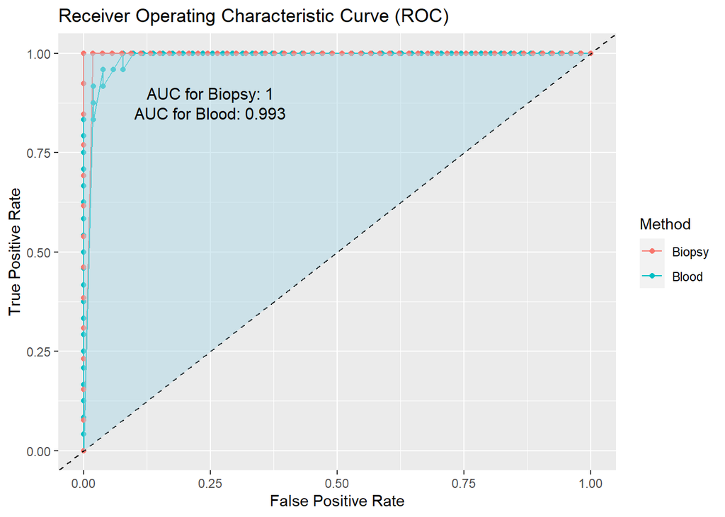

```r
# Biopsy
svm_fit_gse1b <- svm(x = X_gse1b, y = as.factor(y_gse1b))
predictions_gse1b <- svm_fit_gse1b$decision.values
roc_gse1b <- roc(as.factor(y_gse1b), predictions_gse1b)

# Blood
svm_fit_gse4b <- svm(x = X_gse4b, y = as.factor(y_gse4b))
predictions_gse4b <- svm_fit_gse4b$decision.values
roc_gse4b <- roc(as.factor(y_gse4b), predictions_gse4b)

# Calculate distances from top left corner
roc_data <- data.frame(
  Method = c(rep("Blood", length(roc_gse4b$specificities)), rep("Biopsy", length(roc_gse1b$specificities))),
  TPR = c(roc_gse4b$sensitivities, roc_gse1b$sensitivities),
  FPR = c(1 - roc_gse4b$specificities, 1 - roc_gse1b$specificities)
)

roc_data$Distance <- sqrt((roc_data$TPR - 1)^2 + roc_data$FPR^2)


# Recalculate ROC curve for biopsy method
roc_gse1b <- roc(as.factor(y_gse1b), 1 - as.numeric(predictions_gse1b), direction = ">")
auc_gse1b <- auc(roc_gse1b)


roc_gse4b <- roc(as.factor(y_gse4b), as.numeric(predictions_gse4b), direction = ">")
auc_gse1b <- auc(roc_gse1b)
auc_gse4b <- auc(roc_gse4b)



threshold_line <- data.frame(
  x = c(1, rev(roc_gse1b$specificities), 0),
  y = c(1, rev(roc_gse1b$sensitivities), 0)
)

# Plot the ROC curve
insamproc <- ggplot() +
  geom_line(data = roc_data, aes(x = FPR, y = TPR, color = Method)) +
  geom_point(data = roc_data, aes(x = FPR, y = TPR, color = Method)) +
  geom_abline(slope = 1, intercept = 0, linetype = "dashed") +
  geom_polygon(data = threshold_line, aes(x = x, y = y), fill = "lightblue", alpha = 0.5) +
  xlim(0, 1) +
  ylim(0, 1) +
  labs(x = "False Positive Rate", y = "True Positive Rate", title = "Receiver Operating Characteristic Curve (ROC)") +
  annotate("text", x = 0.25, y = 0.9, label = paste("AUC for Biopsy:", round(auc_gse1b, 3)), color = "black", size = 4) +
  annotate("text", x = 0.25, y = 0.85, label = paste("AUC for Blood:", round(auc_gse4b, 3)), color = "black", size = 4)

insamproc
```

## 6.2 In-sample vs Out-of-sample mean accuracy

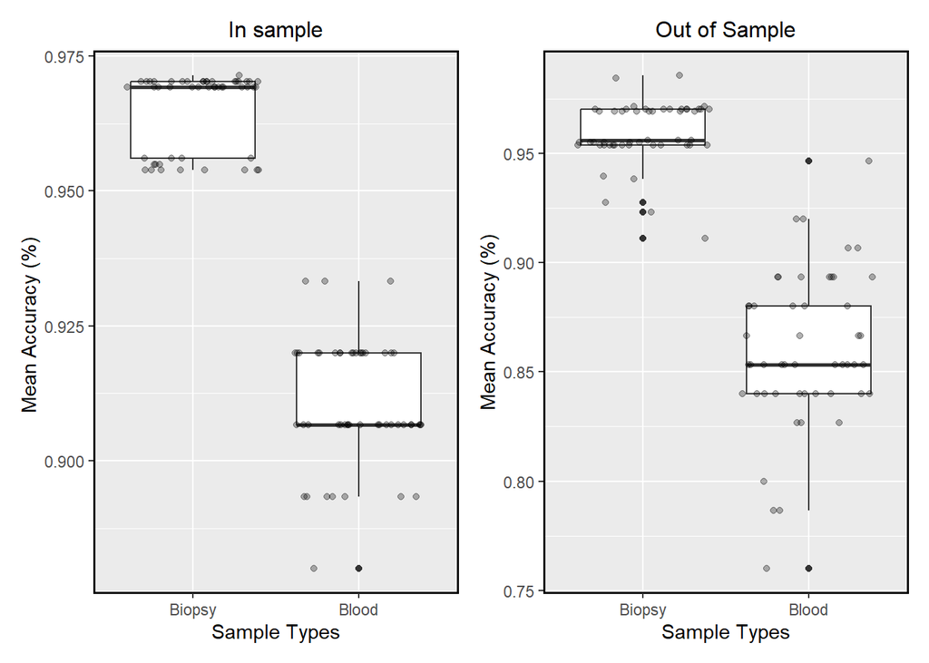

```r
plot_df = data.frame(accuracy = c(
                                  cv_accuracy_gse1c,
                                  cv_accuracy_gse4c),
                     model = c(
                               rep("Biopsy", length(cv_accuracy_gse1c)),
                               rep("Blood", length(cv_accuracy_gse4c))))


outsamp <- ggplot(data = plot_df, aes(x = model, y = accuracy)) +
  geom_boxplot() +
  geom_jitter(alpha = 0.3) +
  labs(title = "Out of Sample",
       x = "Sample Types",
       y = "Mean Accuracy (%)") +
  theme(plot.title = element_text(hjust = 0.5, size = 12),
        panel.border = element_rect(colour = "black", fill = NA, size = 1))


plot_df = data.frame(accuracy = c(cv_accuracy_gse1b,
                                  cv_accuracy_gse4b),
                     model = c(rep("Biopsy", length(cv_accuracy_gse1b)),
                               rep("Blood", length(cv_accuracy_gse4b))))

insamp <- ggplot(data = plot_df, aes(x = model, y = accuracy)) +
  geom_boxplot() +
  geom_jitter(alpha = 0.3) +
  labs(x = "Sample Types", y = "Mean Accuracy (%) ", title = "In sample") +
  theme(plot.title = element_text(hjust = 0.5, size = 12),
        panel.border = element_rect(colour = "black", fill = NA, size = 1))


insamp + outsamp
```

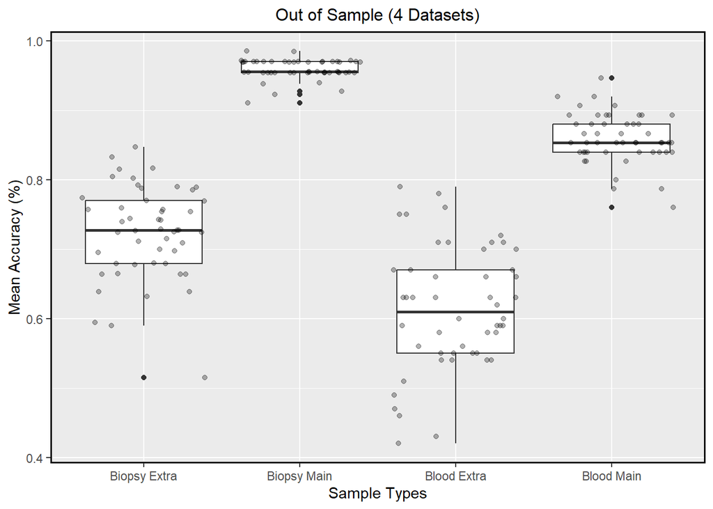

```r
# Add extra datasets to plot_df
plot_df <- data.frame(accuracy = c(
  cv_accuracy_gse1c,
  cv_accuracy_gse4c,
  cv_accuracy_gse1c2,
  cv_accuracy_gse4c2),
  model = c(
    rep("Biopsy Main", length(cv_accuracy_gse1c)),
    rep("Blood Main", length(cv_accuracy_gse4c)),
    rep("Biopsy Extra", length(cv_accuracy_gse1c2)),
    rep("Blood Extra", length(cv_accuracy_gse4c2))
  )
)

# Update the plot
outsamp <- ggplot(data = plot_df, aes(x = model, y = accuracy)) +
  geom_boxplot() +
  geom_jitter(alpha = 0.3) +
  labs(
    title = "Out of Sample (4 Datasets)",
    x = "Sample Types",
    y = "Mean Accuracy (%)"
  ) +
  theme(
    plot.title = element_text(hjust = 0.5, size = 12),
    panel.border = element_rect(colour = "black", fill = NA, size = 1)
  )

outsamp
```

## 6.3 SVM Decision Boundary

### 6.3.1 Blood

```r
# Perform PCA on the data (blood)
pca_result <- prcomp(t(X_gse4c), center = TRUE, scale. = TRUE)
X_pca <- predict(pca_result, newdata = t(X_gse4c))

# Trim the dimensions of y_gse4c to match X_pca
y_trimmed <- y_gse4c[1:nrow(X_pca)]


pca_df <- data.frame(PC1 = X_pca[, 1], PC2 = X_pca[, 2], y_gse4c = as.factor(y_trimmed))

# Train SVM on the PCA-transformed data (blood)
svm_fit4bloodout <- svm(y_gse4c ~ ., data = pca_df, kernel = "linear")

# Create a meshgrid of points to visualize the decision boundary
x1 <- seq(min(pca_df$PC1), max(pca_df$PC1), length = 100)
x2 <- seq(min(pca_df$PC2), max(pca_df$PC2), length = 100)
grid <- expand.grid(PC1 = x1, PC2 = x2)

# Check dimensions of X_gse4c and grid
cat("Dimensions of X_gse4c:", dim(X_gse4c), "\n")
```

```
## Dimensions of X_gse4c: 75 22189
```

```r
cat("Dimensions of grid:", dim(grid), "\n")
```

```
## Dimensions of grid: 10000 2
```

Comment: X_gse4c (Blood sample) and grid has unequal sample and feature distributions, PCA is required to reduce datapoint dimensions in order to create the svm decision boundary.

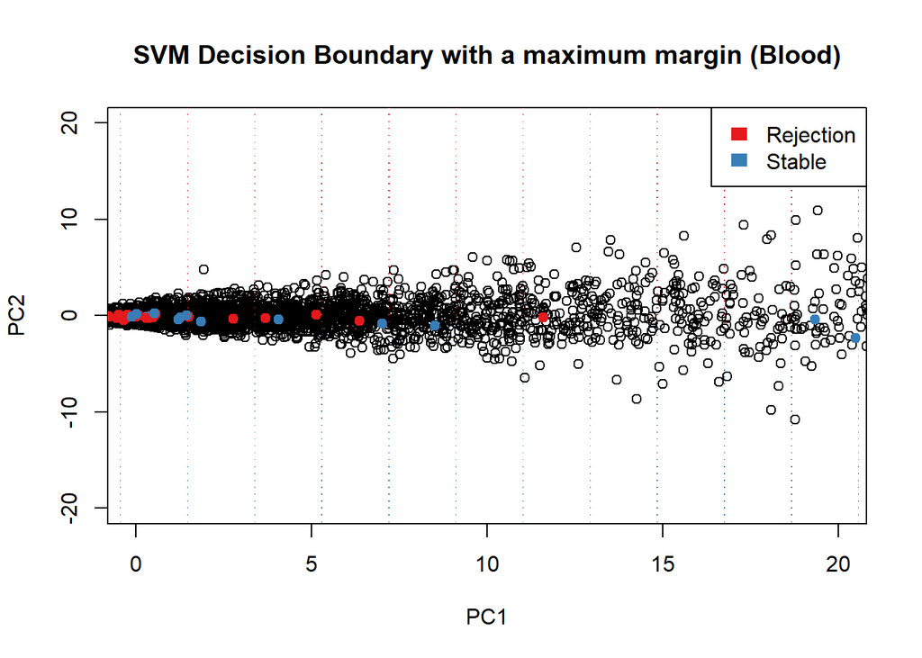

```r
# Make predictions on the meshgrid points
grid$predictions <- predict(svm_fit4bloodout, newdata = grid)

# Plot decision boundary (blood)
#bloodout <- plot(PC2 ~ PC1, data = pca_df, main = "SVM Decision Boundary (Blood)")
#points(PC2 ~ PC1, data = pca_df, col = as.numeric(pca_df$y_gse4c))
#points(PC2 ~ PC1, data = grid, col = grid$predictions, pch = ".", cex = 0.8)


#Clean_version (blood)

# Define color palette for the plot
colors <- brewer.pal(length(levels(pca_df$y_gse4c)), "Set1")

# Plot decision boundary (blood)
bloodout1 <- plot(PC2 ~ PC1, data = pca_df, main = "SVM Decision Boundary with a maximum margin (Blood)", xlim = c(0, 20), ylim = c(-20, 20), xlab = "PC1", ylab = "PC2")
points(PC2 ~ PC1, data = pca_df, col = colors[as.numeric(pca_df$y_gse4c)], pch = 20, cex = 1.5, alpha = 0.7)
points(PC2 ~ PC1, data = grid, col = colors[as.numeric(grid$predictions)], pch = ".", cex = 0.8)
legend("topright", legend = levels(pca_df$y_gse4c), fill = colors, border = NA)
```

```r
# Read the results of the plot

# Determine the predicted class labels for the data points
predicted_labels <- grid$predictions

# Create a subset of the original data frame to match the number of meshgrid points
subset_df <- pca_df[1:nrow(grid), ]

# Create a data frame with the PCA coordinates, true class labels, and predicted class labels
result_df <- data.frame(PC1 = subset_df$PC1, PC2 = subset_df$PC2, True_Labels = subset_df$y_gse4c, Predicted_Labels = as.factor(predicted_labels))


# Remove any missing values
result_df <- na.omit(result_df)

# Assess the accuracy of the SVM decision boundary model
accuracy <- sum(result_df$True_Labels == result_df$Predicted_Labels) / nrow(result_df)
cat("Accuracy:", accuracy, "\n")
```

```
## Accuracy: 0.32
```

According to the blood sample accuracy result, the model achieved a low accuracy of 0.32 for correctly classifying rejection and a stable outcome from gene expression data points. In other words, only 32% of the outcomes in this dataset were correctly identified.

### 6.3.2 Biopsy

```r
# Perform PCA on the data (biopsy)
pca_result1  <- prcomp(t(X_gse1c), center = TRUE, scale. = TRUE)
X_pca1 <- predict(pca_result1 , newdata1 = t(X_gse1c))

# Trim the dimensions of y_gse1c to match X_pca1
y_trimmed1 <- y_gse1c[1:nrow(X_pca1)]

# Create a data frame with PCA-transformed data and response variable (blood)
pca_df1 <- data.frame(PC1b = X_pca1[, 1], PC2b = X_pca1[, 2], y_gse1c = as.factor(y_trimmed1))

# Train SVM on the PCA-transformed data (biopsy)
svm_fit4biopsyout <- svm(y_gse1c ~ ., data = pca_df1, kernel = "linear")

# Create a meshgrid of points to visualize the decision boundary
x1b <- seq(min(pca_df1$PC1b), max(pca_df1$PC1b), length = 100)
x2b <- seq(min(pca_df1$PC2b), max(pca_df1$PC2b), length = 100)
grid1 <- expand.grid(PC1b = x1b, PC2b = x2b)


# Check dimensions of X_gse4c and grid
cat("Dimensions of X_gse1c:", dim(X_gse1c), "\n")
```

```
## Dimensions of X_gse1c: 66 22189
```

```r
cat("Dimensions of grid:", dim(grid1), "\n")
```

```
## Dimensions of grid: 10000 2
```

Comment: X_gse1c (Biopsy sample) and grid has unequal sample and feature distributions, PCA is required to reduce datapoint dimensions in order to create the svm decision boundary.

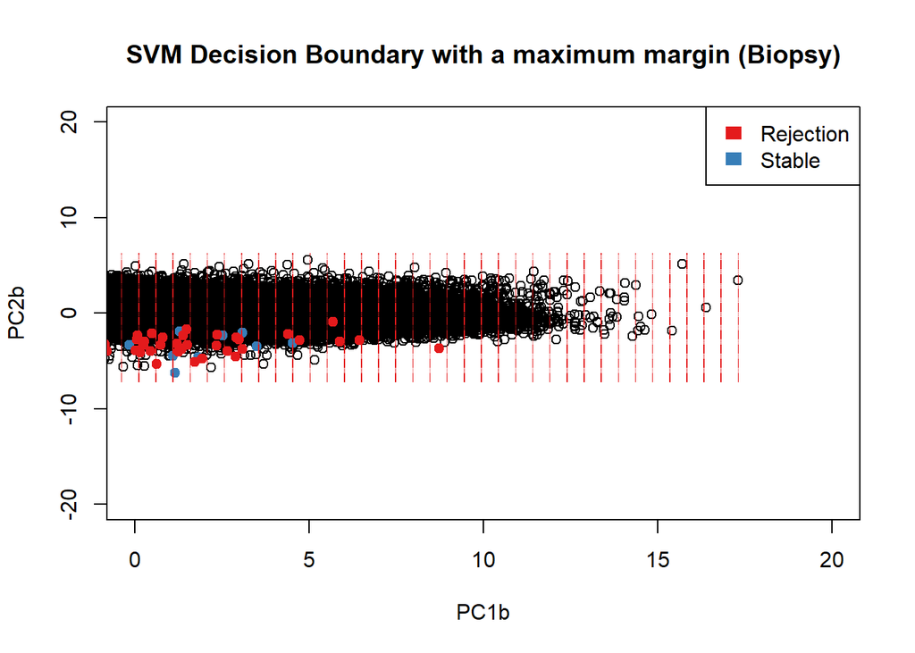

```r
# Perform prediction on the meshgrid points
predictions1 <- predict(svm_fit4biopsyout, newdata = grid1)

# Add the predictions to the grid1 data frame
grid1$predictions1 <- predictions1


# Plot decision boundary (biopsy)
#biopsyout <- plot(PC2b ~ PC1b, data = pca_df1, main = "SVM Decision Boundary (Biopsy)")
#points(PC2b ~ PC1b, data = pca_df1, col = as.numeric(pca_df1$y_gse1c))
#points(PC2b ~ PC1b, data = grid1, col = grid1$predictions1, pch = ".", cex = 0.8)


#Clean_version (biopsy)

# Define color palette for the plot
colors <- brewer.pal(length(levels(pca_df1$y_gse1c)), "Set1")

# Plot decision boundary (biopsy)
biopsyout1 <- plot(PC2b ~ PC1b, data = pca_df1, main = "SVM Decision Boundary with a maximum margin (Biopsy)", xlim = c(0, 20), ylim = c(-20, 20), xlab = "PC1b", ylab = "PC2b")
points(PC2b ~ PC1b, data = pca_df1, col = colors[as.numeric(pca_df1$y_gse1c)], pch = 20, cex = 1.5, alpha = 0.7)
points(PC2b ~ PC1b, data = grid1, col = colors[as.numeric(grid1$predictions1)], pch = ".", cex = 0.8)
legend("topright", legend = levels(pca_df1$y_gse1c), fill = colors, border = NA)
```

```r
# Determine the predicted class labels for the data points
predicted_labels1 <- grid1$predictions1

# Create a subset of the original data frame to match the number of meshgrid1 points
subset_df1 <- pca_df1[1:nrow(grid1), ]


# Perform prediction on the meshgrid points
predictions1 <- predict(svm_fit4biopsyout, newdata = grid1)

if (length(predictions1) == 0) {
  stop("No predictions generated. Check if the SVM model was trained successfully.")
}

# Add the predictions to the grid1 data frame
if (nrow(grid1) == length(predictions1)) {
  grid1$predictions1 <- predictions1
} else {
  stop("Mismatch in the number of rows between grid1 and predictions1.")
}



# Create a data frame with the PCA coordinates, true class labels, and predicted class labels
result_df1 <- data.frame(PC1b = subset_df1$PC1b, PC2b = subset_df1$PC2b, True_Labels1 = subset_df1$y_gse1c, predicted_labels1 = as.factor(predictions1))

# Remove missing values
result_df1 <- na.omit(result_df1)

#  accuracy
accuracy1 <- sum(result_df1$True_Labels1 == result_df1$predicted_labels1) / nrow(result_df1)
cat("Accuracy:", accuracy1, "\n")
```

```
## Accuracy: 0.8030303
```

In this case, the biopsy decision boundary model showed 0.80 percent of the svm model correctly classifying correct rejection and stable outcome in the biopsy dataset. To put it simply, approximately 80% of gene expression data points have been correctly classified.

We conclude that the biopsy svm decision boundary has a higher accuracy value than blood, implying that the biopsy model performs better overall.

Based on cross-validation and classification algorithms developed from three SVM models, including ROC Curve, in-sample and out-of-sample mean accuracy, and decision boundary results, the biopsy is a better predictor of kidney transplant success in the early stage than blood. The successful results also indicated that the all-robustness models should be integrated with the visualization method in the R Shiny App.

## 6.4 Top 8 genes differentially expressed genes - Blood & Biopsy

```r
intersect(top4blood$ID, top4biopsy$ID)
```

```
## [1] "CCR2"    "ITGA4"   "PTPRC"   "PDE8A"   "ST8SIA4" "SLC9A9"  "MYCL"
## [8] "CLEC7A"
```

### 6.4.1 Top 8 Genes Distance Matrix

```r
CCR2 <- c(1.2, 2.3, 0.8, 1.5)    # Expression values for gene CCR2
ITGA4 <- c(0.5, 2.1, 1.8, 1.2)   # Expression values for gene ITGA4
PTPRC <- c(0.9, 1.7, 1.3, 1.8)   # Expression values for gene PTPRC
PDE8A <- c(1.5, 0.7, 2.0, 1.4)   # Expression values for gene PDE8A
ST8SIA4 <- c(2.2, 1.1, 1.6, 0.9)  # Expression values for gene ST8SIA4
SLC9A9 <- c(0.8, 1.9, 1.2, 1.3)  # Expression values for gene SLC9A9
MYCL <- c(1.1, 1.8, 1.4, 0.7)  # Expression values for gene MYCL
CLEC7A <- c(1.6, 0.9, 1.3, 1.1)  # Expression values for gene CLEC7A

# Create a matrix to store the pairwise distances
gene_distances <- matrix(0, nrow = 8, ncol = 8)

# Calculate the Euclidean distance between all pairs of genes
gene_distances[1, 2] <- sqrt(sum((CCR2 - ITGA4)^2))
gene_distances[1, 3] <- sqrt(sum((CCR2 - PTPRC)^2))
gene_distances[1, 4] <- sqrt(sum((CCR2 - PDE8A)^2))
gene_distances[1, 5] <- sqrt(sum((CCR2 - ST8SIA4)^2))
gene_distances[1, 6] <- sqrt(sum((CCR2 - SLC9A9)^2))
gene_distances[1, 7] <- sqrt(sum((CCR2 - MYCL)^2))
gene_distances[1, 8] <- sqrt(sum((CCR2 - CLEC7A)^2))
gene_distances[2, 3] <- sqrt(sum((ITGA4 - PTPRC)^2))
gene_distances[2, 4] <- sqrt(sum((ITGA4 - PDE8A)^2))
gene_distances[2, 5] <- sqrt(sum((ITGA4 - ST8SIA4)^2))
gene_distances[2, 6] <- sqrt(sum((ITGA4 - SLC9A9)^2))
gene_distances[2, 7] <- sqrt(sum((ITGA4 - MYCL)^2))
gene_distances[2, 8] <- sqrt(sum((ITGA4 - CLEC7A)^2))
gene_distances[3, 4] <- sqrt(sum((PTPRC - PDE8A)^2))
gene_distances[3, 5] <- sqrt(sum((PTPRC - ST8SIA4)^2))
gene_distances[3, 6] <- sqrt(sum((PTPRC - SLC9A9)^2))
gene_distances[3, 7] <- sqrt(sum((PTPRC - MYCL)^2))
gene_distances[3, 8] <- sqrt(sum((PTPRC - CLEC7A)^2))
gene_distances[4, 5] <- sqrt(sum((PDE8A - ST8SIA4)^2))
gene_distances[4, 6] <- sqrt(sum((PDE8A - SLC9A9)^2))
gene_distances[4, 7] <- sqrt(sum((PDE8A - MYCL)^2))
gene_distances[4, 8] <- sqrt(sum((PDE8A - CLEC7A)^2))
gene_distances[5, 6] <- sqrt(sum((ST8SIA4 - SLC9A9)^2))
gene_distances[5, 7] <- sqrt(sum((ST8SIA4 - MYCL)^2))
gene_distances[5, 8] <- sqrt(sum((ST8SIA4 - CLEC7A)^2))
gene_distances[6, 7] <- sqrt(sum((SLC9A9 - MYCL)^2))
gene_distances[6, 8] <- sqrt(sum((SLC9A9 - CLEC7A)^2))
gene_distances[7, 8] <- sqrt(sum((MYCL - CLEC7A)^2))

# Fill in the lower triangle of the matrix with the corresponding distances
gene_distances[lower.tri(gene_distances)] <- t(gene_distances)[lower.tri(gene_distances)]

# Set row and column names
genes <- c("CCR2", "ITGA4", "PTPRC", "PDE8A", "ST8SIA4", "SLC9A9", "MYCL", "CLEC7A")
rownames(gene_distances) <- genes
colnames(gene_distances) <- genes

# Print the matrix of pairwise distances
gene_distances
```

```
##              CCR2     ITGA4     PTPRC     PDE8A  ST8SIA4    SLC9A9      MYCL
## CCR2    0.0000000 1.2727922 0.8888194 2.0248457 1.854724 0.7211103 1.1224972
## ITGA4   1.2727922 0.0000000 0.9643651 1.7435596 2.004994 0.7071068 0.9273618
## PTPRC   0.8888194 0.9643651 0.0000000 1.4177447 1.717556 0.5567764 1.1269428
## PDE8A   2.0248457 1.7435596 1.4177447 0.0000000 1.029563 1.6062378 1.4899664
## ST8SIA4 1.8547237 2.0049938 1.7175564 1.0295630 0.000000 1.7088007 1.3341664
## SLC9A9  0.7211103 0.7071068 0.5567764 1.6062378 1.708801 0.0000000 0.7071068
## MYCL    1.1224972 0.9273618 1.1269428 1.4899664 1.334166 0.7071068 0.0000000
## CLEC7A  1.5905974 1.7058722 1.2727922 0.7937254 0.728011 1.3000000 1.1090537
##            CLEC7A
## CCR2    1.5905974
## ITGA4   1.7058722
## PTPRC   1.2727922
## PDE8A   0.7937254
## ST8SIA4 0.7280110
## SLC9A9  1.3000000
## MYCL    1.1090537
## CLEC7A  0.0000000
```

### 6.4.2 Top 8 Genes Distances Heatmap

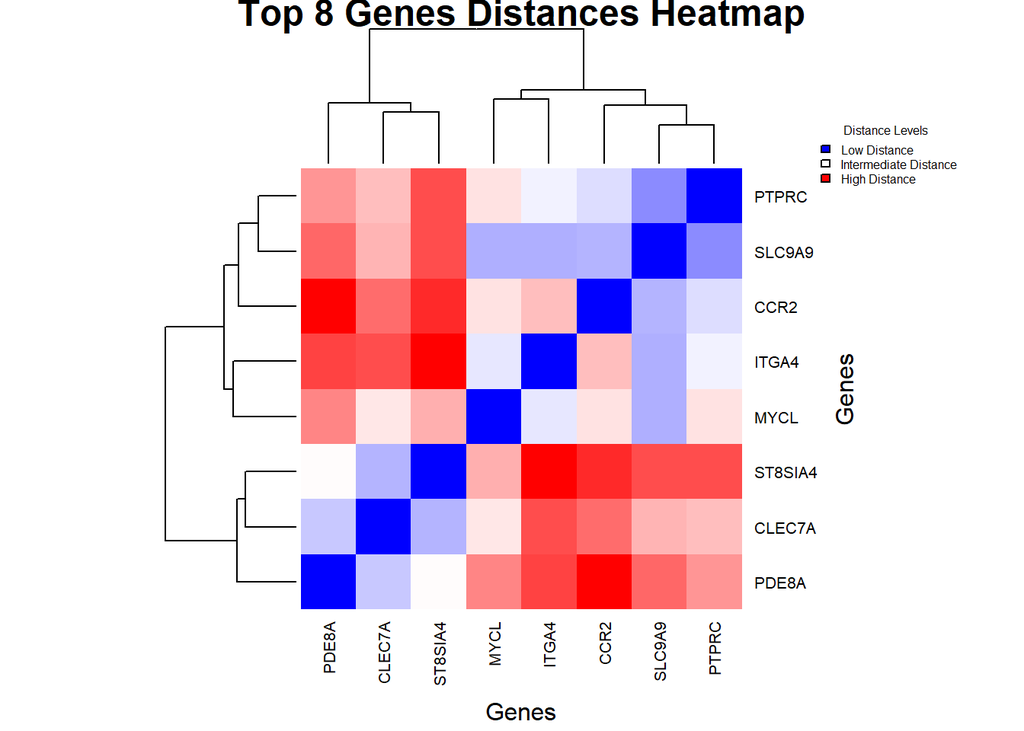

```r
# Set the color palette for the heatmap
heatmap_colors <- colorRampPalette(c("blue", "white", "red"))(n = 100)

# Create the heatmap plot
top5 <- heatmap(gene_distances,
        col = heatmap_colors,
        scale = "none",
        margins = c(5, 5),
        main = "Top 8 Genes Distances Heatmap",
        xlab = "Genes",
        ylab = "Genes",
        cexRow = 0.8,
        cexCol = 0.8)

# Add a legend explaining the color levels
legend("topright",
        legend = c("Low Distance", "Intermediate Distance", "High Distance"),
        fill = c("blue", "white", "red"),
        bty = "n",
        title = "Distance Levels",
       cex = 0.5)
```

### 6.4.3 Top 8 Distance Accuracy

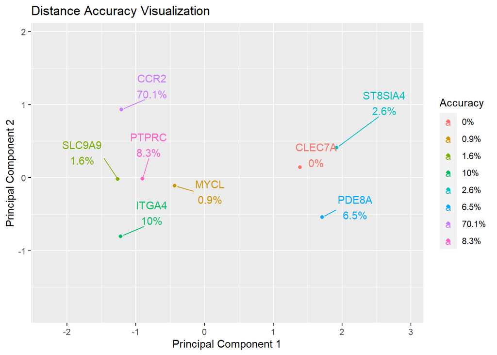

```r
# Perform PCA
pca <- prcomp(gene_distances)

# Calculate the variance explained by each principal component
variance <- pca$sdev^2
total_variance <- sum(variance)
variance_ratio <- variance / total_variance
accuracy <- paste0(round(variance_ratio * 100, 1), "%")

# Create a data frame with gene names, PCA coordinates, accuracy, and color
pca_data <- data.frame(Gene = genes, PC1 = pca$x[, 1], PC2 = pca$x[, 2], Accuracy = accuracy, Color = accuracy)

# Plot PCA with gene names, accuracy, and color
pca_plot <- ggplot(pca_data, aes(PC1, PC2, label = Gene, color = Color)) +
  geom_point() +
  geom_text_repel(aes(label = paste0(Gene, "\n", Accuracy)), box.padding = 1, point.padding = 0.2, nudge_x = 0.1, nudge_y = 0.1) +
  labs(x = "Principal Component 1", y = "Principal Component 2", color = "Accuracy") +
  ggtitle("Distance Accuracy Visualization") +
  coord_cartesian(xlim = c(min(pca_data$PC1) - 1, max(pca_data$PC1) + 1),
                  ylim = c(min(pca_data$PC2) - 1, max(pca_data$PC2) + 1))

# Display the PCA plot
print(pca_plot)
```

```r
pca_acc <- data.frame(Gene = genes, Accuracy = accuracy)

# Print gene names and accuracy
print(pca_acc)
```

```
##      Gene Accuracy
## 1    CCR2    70.1%
## 2   ITGA4      10%
## 3   PTPRC     8.3%
## 4   PDE8A     6.5%
## 5 ST8SIA4     2.6%
## 6  SLC9A9     1.6%
## 7    MYCL     0.9%
## 8  CLEC7A       0%
```